[figure not shown]

# Shiny как ГИС-инструмент конечного пользователя

Open Cafe выступление на IV Конференции сообщества природоохранных ГИС в России Национальный парк «Валдайский», 04 октября 2019 г.

Никита Платонов (ИПЭЭ РАН)

Обновлено: 2019-10-04 09:58

# Демонстрация результатов ГИС

## Способы визуализации пространственных данных

- Копия экрана Хорошо для мануалов
- Оформление в виде рисунка
  - Средства ГИС (экспорт, QGIS Print Composer) Требует некоторые усилия на создания
  - R например
- Интерактивная оформление
- Приложение – ГИС лишь с необходимым или даже расширенным функционалом (мини-ГИС).

## Копия экрана

[figure not shown]

## R: статическая визуализация

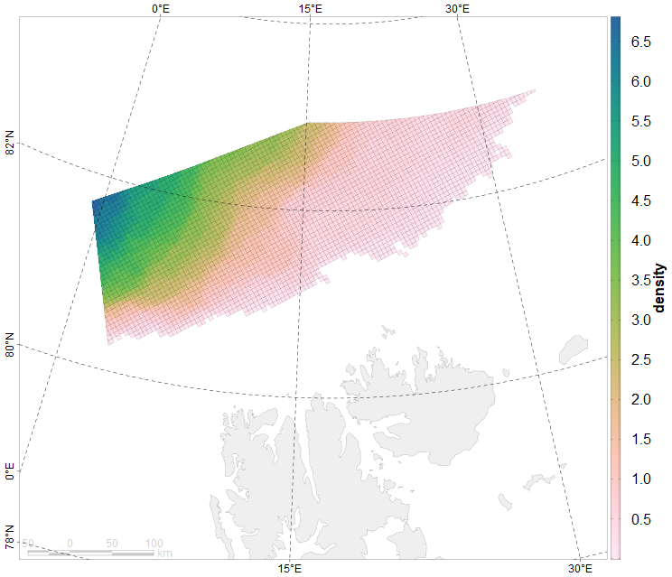

## R: интерактивная визуализация

[interactive chart not shown]

# Shiny

## Бэкграунд; модули Shiny

Обязательно: R (написание скриптов)

Необязательно, но не лишне: HTML, CSS

- + `ui` (переменная) – интерфейс
- + `server(input, output, session)` (функция) – функционал
- = `app(ui=ui,server=server)` (функция) – приложение

## Структура Shiny

- Элементы интерфейса
  - Компоновка элементов (например, `shiny::fluidPage()`, `shinydashboard::dashboardPage()`)
    - Навигационные элементы переход на вкладку, переход по ссылке
    - Входные параметры: `*Input`
    - Вывод: `*Output`
- Связка ui-server: `*Output` –> `render*`
- forcing
  - параметры опциональной сессии (`session`), включая парсинг URL
  - явное действие (`actionButton()`, `actionLink()`)
  - реактивность – латентное отслеживание изменения входных параметров (`reactive()`, `eventReactive()`, `reactiveValues()`)

# Проекты WWF по планированию сети ключевых морских территорий

## Выявление ключевых районов биоразнообразия

Тематика и географических охват:

- «Разработка системы новых морских охраняемых районов в арктических морях России» (завершен)
- «Разработка научно обоснованной системы морских охраняемых районов для Печорского моря»
- «Выявление пан-арктической сети районов, обеспечивающих репрезентативность биологического разнообразия и ключевых экологических функций и обеспечивающих устойчивость экосистем Северного Ледовитого океана и арктических морей (PAMPAN)»
- «Построение сети перспективных охраняемых природных территорий на основе биологических и средообразующих данных для дальневосточных морей»

## Реализация проектов

- Формирование команды экспертов по предметным областям
  - Ихтиологи
  - Орнитологи
  - Мормлекологи
- Подготовка слоев данных
- Разработка сценариев, подготовка и запуск Marxan (итерационно)
- Анализ, экспертиза, пост-анализ

## Использование инструмента «Marxan»

«Marxan» - инструмент для стохастического поиска (эмуляция отжига) лучшей конфигурации территориальных единиц

Минимизация целевой функции:

∑<sub>*P**U**s*</sub>*C**o**s**t* + *B**L**M*∑<sub>*P**U**s*</sub>*B**o**u**n**d**a**r**y* + ∑<sub>*C**o**n**V**a**l**u**e*</sub>*S**P**F* × *P**e**n**a**l**t**y* + *C**o**s**t**T**h**e**s**h**o**l**d**P**e**n**a**l**t**y*

1. ∑<sub>*P**U**s*</sub>*C**o**s**t* - стоимость площади элемента
2. *B**L**M*∑<sub>*P**U**s*</sub>*B**o**u**n**d**a**r**y* - стоимость протяженности границ
3. ∑<sub>*C**o**n**V**a**l**u**e*</sub>*S**P**F* × *P**e**n**a**l**t**y* - штраф за недостижение целевого показателя
4. *C**o**s**t**T**h**e**s**h**o**l**d**P**e**n**a**l**t**y* - штраф за перевыполнение целевого показателя (*не использовался*)

# «Accenter»

## «Accenter»

Инструмент для пост-анализа – анализ результатов, полученных в Marxan.

Основная цель – расширенный аналог “Identify Feature” из QGIS

Реализация:

- Dashboard для HD разрешения
- Мобильная версия поддерживается, но без оптимизации.
- Предпочтение на `reactive`-элементов над `action*`-элементами

# Демонстрация

[interactive chart not shown]

# Резюмируя:

Выбор наиболее удобного, несложного для реализации, перспективного функционала

## Дополнительная информация

### Проект

[figure not shown]

[figure not shown]

### Докладчик

- Платонов Никита Геннадьевич ✉
- [ИПЭЭ РАН](http://www.sev-in.ru) – 85 лет в 2019 г. 🎂
- [Постоянно действующая экспедиция РАН по изучению животных Красной книги Российской Федерации и других особо важных животных фауны России](http://www.sevin-expedition.ru)
- [Программа изучения белого медведя в Российской Арктике](http://bear.sevin-expedition.ru)